# Captura-recaptura espacial (SCR)

José Jiménez (CSIC-IREC) email: jose.jimenez@csic.es

04/8/2022

## Introducción

Los modelos de captura-recaptura espacialmente explícitas (SCR) son herramientas avanzadas que sirven para realizar inferencias sobre los tamaños poblacionales (número y densidad) y las distribuciones espaciales de las especies, y por ello pueden ser utilizadas para estudios de selección de hábitat, conectividad, co-ocurrencia, etc. Los modelos abiertos (OpenSCR) permiten estimar además parámetros demográficos (natalidad y mortalidad/supervivencia) que son también espacialmente explícitos. Los modelos SCR resultan herramientas imprescindibles para conocer el estado de conservación real de especies elusivas.

En los modelos SCR originales se usan sólo los eventos con identificación. Los **eventos sin identificación** se descartan. Esto es muy común cuando los datos a utilizar en los modelos SCR son, por ejemplo, basados en muestreos de genética no invasiva, para las cuales habrá una parte en los que no se podrá llegar a la identificación individual. También nos ocurre en cámaras-trampa, cuando obtenemos fotos borrosas o parciales de los índividuos. Veremos más tarde como usar esos eventos sin identificación en los modelos *random thinning-SCR* o modelos de captura-recaptura espacial con aclareo aleatorio (Jiménez et al., 2021).

Hay dos grupos de aproximaciones a SCR: MLE, con software de extraordinaria calidad, de uso sencillo y salidas gráficas muy atractivas, como *secr* (Efford, 2020) y *oSCR* (Sutherland et al., 2018), y bayesianas (Royle et al., 2014), que pueden resultar más complejas de aprender, pero que son extraordinariamente versátiles y pueden ser modificadas para adaptarse a diferentes necesidades. Estas últimas son las que vamos a estudiar.Vamos a ejecutarlas usando R (R Core Team, 2022) y Nimble (De Valpine et al., 2017).

Recomiendo repetir los análisis que se ejecutan aquí, cambiando los valores de $set.seed()$ que controlan la aleatoriedad de las simulaciones. Para ampliar conocimientos resulta adecuado leer las referencias de este documento y el libro Spatial Capture-Recapture de Royle et al. (2017) https://www.sciencedirect.com/book/9780124059399/spatial- capture-recapture.

## Simulación de datos

Vamos a simular datos en $R$ y a ejecutar el modelo SCR. En este caso vamos a trabajar con detección/no detección,con una distribución binomial, aunque es muy sencillo cambiarlo y trabajar con conteos, usando una distribución de Poisson (podeis verlo en el código). El nivel de precisión que podemos obtener con estas estimas va a depender en buena parte del número de recapturas, que a su vez depende de la detectabilidad ($\lambda_{0}$), el número de ocasiones de muestreo $K$ y la relación entre la distancia entre trampas/cámaras y el movimiento de los animales ($\sigma$). Para generar los datos simulados vamos a cargar varios paquetes de $R$ y un conjunto de funciones que he compilado y modificado para ser utilizadas aquí.

```r
source("SCR_functions.R")  # Funciones de interés
library(scrbook)           # Atención, scrbook no está en CRAN
library(nimble)
library(mcmcOutput)
library(lattice)
library(coda)
```

Datos a simular. Aquí podeis cambiar vosotros los valores de *N* y de *K*. La detectabilidad, si queréis cambiarla, debéis modificar la función original *SimSCR0*.

```r
N <- 50  # Tamaño de población
K <- 15  # Ocasiones de muestreo
J <- 100 # Número de trampas
```

Vamos a generar nuestros datos. Los veremos gráficamente y exploraremos con *str*:

```r
data <- SimSCR0(N=N, K=K, array3d = TRUE, discard0=TRUE, rnd=2013)
str(data)
```

```
## List of 10
##  $ Y       : int [1:38, 1:100, 1:15] 0 0 0 0 0 0 0 0 0 0 ...
##  $ traplocs: int [1:100, 1:2] 1 1 1 1 1 1 1 1 1 1 ...
##  $ xlim    : num [1:2] -0.25 11.25
##  $ ylim    : num [1:2] -0.25 11.25
##  $ N       : num 50
##  $ p0      : num 0.1
##  $ alpha1  : num 2
##  $ sigma   : num 0.5
##  $ K       : num 15
##  $ S       : num [1:50, 1:2] 5.08 10.7 8.78 8.53 2.65 ...
##   ..- attr(*, "dimnames")=List of 2
##   .. ..$ : NULL
##   .. ..$ : chr [1:2] "sx" "sy"
```

```r
S<-data$S    # Ubicación espacial de todos los animales generados
y3d<-data$Y  # Matriz de captura nind x J x K

(detections <- sum(y3d)) # Total de detecciones
```

```
## [1] 94
```

```r
(nind <- dim(y3d)[1])    # individuos detectados
```

```
## [1] 38
```

```r
X <- data$traplocs       # trampas (o cámaras-trampa)
K <- data$K              # ocasiones de captura
J <- nrow(X)             # total de cámaras

M <- 150 # Aumentado de datos

# Espacio de estados
xlim <- data$xlim        # ubicaciones x que limitan el espacio de estados
ylim <- data$ylim        # ubicaciones y que limitan el espacio de estados
area <- diff(xlim)*diff(ylim)       # área afectada por el muestreo

y <- apply(y3d,c(1,2),sum); str(y)  # matriz de captura reducida sobre K
```

```
##  int [1:38, 1:100] 0 0 0 0 0 0 0 0 0 0 ...
```

```r
# Aumentado de datos:
yaug<-array(0,c(M,J))
yaug[1:nind,]<-y[1:nind,]
```

Vamos a plotear las capturas y crear el spiderplot. En el spiderplot representamos las trampas o detectores (en este caso utilizamos cruces; en la versión standard usando *scrbook* son puntos). Con puntos en rojo, representamos los individuos de la poblacion, diferenciando con relleno los observados, y con solo contornos, los no observados. Los círculos en gris transparentes son las observaciones realizadas en cada camara trampa, y tienen un tamaño proprorcional al número de observaciones. Los puntos en violeta son promedio de las detecciones de cada individuo en el total de cámaras donde se ha detectado, y vienen a ser una aproximación naïve de los centros de actividad. Las líneas en negro representan el movimiento del animal entre diferentes trampas (que lo denominamos recapturas espaciales).

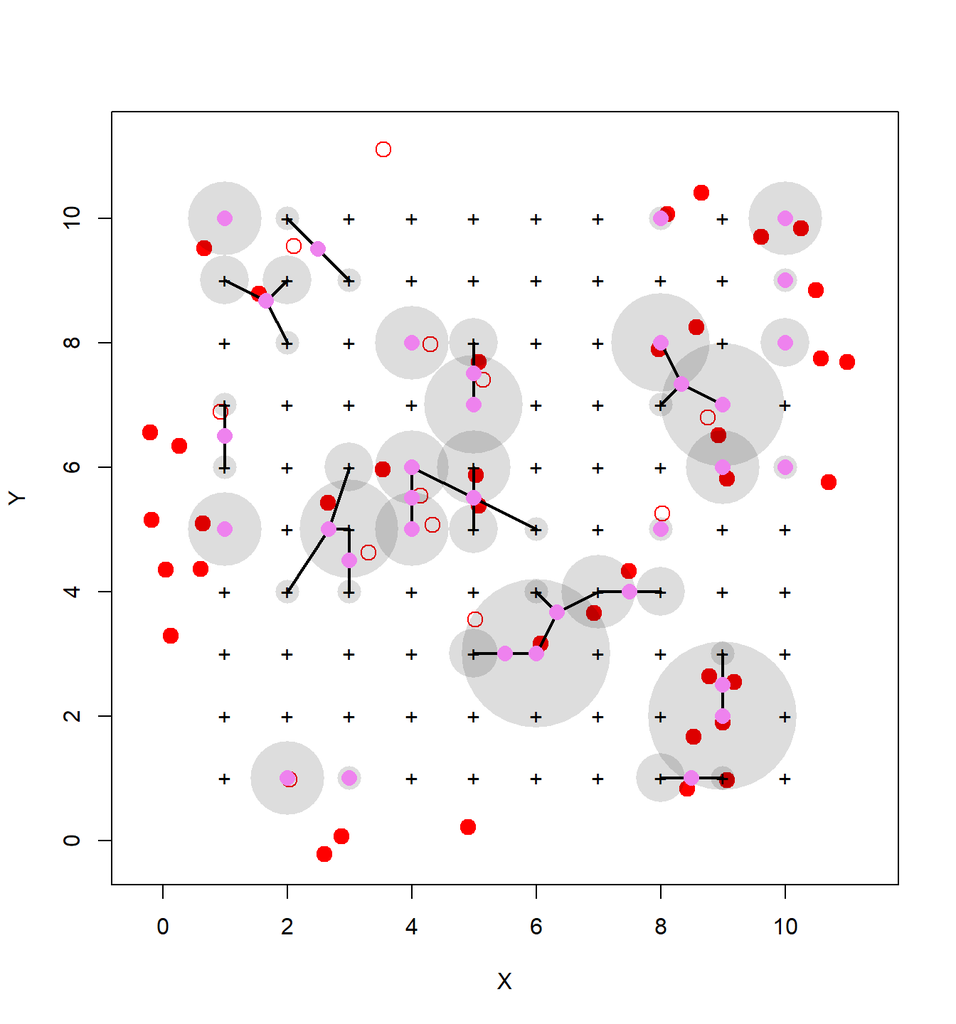

```r
captured<-apply(y3d,1,sum)
captured[captured>1]<-1
captured<-(1:nind)*captured
# Preparamos para hacer la representación del número de capturas por trampa
datn<-apply(y3d, c(2,3), sum)
tot<-apply(datn, 1,sum)

plot(X, xlim=xlim, ylim=ylim, pch="+", type="n", xlab="X", ylab="Y",
     asp=TRUE)
points(S, pch=1, col="red", cex=1.5) # capturados: puntos sólidos
points(S[captured,], pch=16, col="red", cex=1.5)
symbols(X, circles=tot/5, inches=F, bg="#00000022", fg=NULL, add=T)
points(X, pch="+", cex=1)
spiderplotJJ4(y3d, X, buffer=2, lwd=2)
```

## Código SCR

```r
## define the model
code <- nimbleCode({

  p0 ~ dbeta(1,1)
  sigma ~ dunif(0,10)
  psi ~ dunif(0,1)

  for(i in 1:M){
    z[i] ~ dbern(psi)
    s[i,1] ~ dunif(xlim[1],xlim[2])
    s[i,2] ~ dunif(ylim[1],ylim[2])
    d2[i,1:J] <- pow(s[i,1]-X[1:J,1],2) + pow(s[i,2]-X[1:J,2],2)
    p[i,1:J] <- p0*exp(-d2[i,1:J]/(2*sigma^2))*z[i]

    for(j in 1:J){
      y[i,j] ~ dbinom(p[i,j],K)
      #y[i,j] ~ dpois(p[i,j]*K) # Alternativamente podemos usar una
                                # distribución de Poisson para trabajar
                                # con conteos
    }
  }

  N <- sum(z[1:M])
  D <- N/area
})
```

## Preparamos constantes, datos e inicios

Preparamos las constantes:

```r
str(constants <- list(M=M,        # aumentado de datos
                      K=K,        # ocasiones de muestreo
                      J=J,        # número de trampas
                      area=area)) # área del espacio de estados
```

```
## List of 4
##  $ M   : num 150
##  $ K   : num 15
##  $ J   : int 100
##  $ area: num 132
```

… los datos…

```r
str( data   <-   list(y=yaug,     # matriz de capturas reducida sobre K
                      X=X,        # matriz de coordenadas de las trampas
                      xlim=xlim,  # extremos x del espacio de estados
                      ylim=ylim)) # extremos y del espacio de estados
```

```
## List of 4
##  $ y   : num [1:150, 1:100] 0 0 0 0 0 0 0 0 0 0 ...
##  $ X   : int [1:100, 1:2] 1 1 1 1 1 1 1 1 1 1 ...
##  $ xlim: num [1:2] -0.25 11.25
##  $ ylim: num [1:2] -0.25 11.25
```

… y los inicios. Para un correcto funcionamiento, generamos un conjunto de $M$ coordenadas de centros de actividad en el espacio de estados (*s.start*), y $M$ valores de *z* que para evitar contradecir la realidad, vamos a darle sólo valores de “1” a los que correponden a individuos capturados, y a los demás, generamos valores 0/1 con una distribución binomial. Los valores de inicio restantes los generamos al azar con funciones uniformes, de forma que sean compatibles con la información a *a priori* del código:

```r
# Inicios para las ubicaciones latentes
sst <- cbind(runif(M,xlim[1],xlim[2]),runif(M,ylim[1],ylim[2]))
for(i in 1:nind){
  sst[i,1] <- mean( X[yaug[i,]>0,1] )
  sst[i,2] <- mean( X[yaug[i,]>0,2] )
}
zd<-c(rep(1, nind), rbinom((M-nind),1,0.2))

str( inits   <-  list(p0=runif(1,0,1),    # probabilidad basal de detección
                      sigma=runif(1,0,2), # parametrización de sigma
                      psi=runif(1,0,1),   # parámetro de aumentado de datos
                      s=sst,              # ubicaciones de inicio
                      z=zd))              # está o no en la población
```

```
## List of 5
##  $ p0   : num 0.114
##  $ sigma: num 1.25
##  $ psi  : num 0.263
##  $ s    : num [1:150, 1:2] 5 10 9 8.5 2.67 ...
##  $ z    : num [1:150] 1 1 1 1 1 1 1 1 1 1 ...
```

Parámetros que vamos a monitorizar

```r
# Añado s y z para generar después la ubicación de los centros de actividad
params <- c('N', 'D', 'sigma','psi', 'p0','s','z')
```

## Compilamos y ejecutamos:

```r
Rmodel <- nimbleModel(code=code, constants=constants, data=data, inits=inits)
```

```
## Defining model
```

```
## Building model
```

```
## Setting data and initial values
```

```
## Running calculate on model
##   [Note] Any error reports that follow may simply reflect missing values in model variables.
```

```
## Checking model sizes and dimensions
```

```r
Rmodel$initializeInfo()  # Conveniente para ver los inicios
```

```
##   [Note] All model variables are initialized.
```

```r
Rmodel$calculate()
```

```
## [1] -1631.858
```

```r
Cmodel <- compileNimble(Rmodel)
```

```
## Compiling
##   [Note] This may take a minute.
##   [Note] Use 'showCompilerOutput = TRUE' to see C++ compilation details.
```

```r
mcmc<-configureMCMC(Rmodel, monitors=params)
```

```
## ===== Monitors =====
## thin = 1: D, N, p0, psi, s, sigma, z
## ===== Samplers =====
## RW sampler (303)
##   - p0
##   - sigma
##   - psi
##   - s[]  (300 elements)
## binary sampler (150)
##   - z[]  (150 elements)
```

```r
# Para muestrear conjuntamente las coordenadas x, y de s
mcmc$removeSamplers("s")
ACnodes <- paste0("s[", 1:constants$M, ", 1:2]")
for(node in ACnodes) {
  mcmc$addSampler(target = node,
                  type = "AF_slice",
                  control = list(adaptScaleOnly = TRUE),
                  silent = TRUE)
}

MCMC <- buildMCMC(mcmc)

CompMCMC <- compileNimble(MCMC, project = Rmodel)
```

```
## Compiling
##   [Note] This may take a minute.
##   [Note] Use 'showCompilerOutput = TRUE' to see C++ compilation details.
```

```r
nb = 1000
ni = 5000 + nb
nc = 3

start.time2<-Sys.time()
outNim <- runMCMC(CompMCMC, niter = ni , nburnin = nb , nchains =  nc,inits=inits,
                  setSeed = FALSE, progressBar = TRUE, samplesAsCodaMCMC = TRUE)
```

```
## Running chain 1 ...
```

```
## |-------------|-------------|-------------|-------------|
## |-------------------------------------------------------|
```

```
## Running chain 2 ...
```

```
## |-------------|-------------|-------------|-------------|
## |-------------------------------------------------------|
```

```
## Running chain 3 ...
```

```
## |-------------|-------------|-------------|-------------|
## |-------------------------------------------------------|
```

```r
end.time<-Sys.time()
end.time-start.time2 # tiempo de ejecución
```

```
## Time difference of 8.020626 mins
```

## Resultados

Compararemos lo simulado con los valores posteriores, y así podemos tener una idea de que tal funciona nuestro modelo.

```r
summary(outNim[,c('N','D','p0','psi', 'sigma')])
```

```
##
## Iterations = 1:5000
## Thinning interval = 1
## Number of chains = 3
## Sample size per chain = 5000
##
## 1. Empirical mean and standard deviation for each variable,
##    plus standard error of the mean:
##
##          Mean      SD  Naive SE Time-series SE
## N     50.8733 4.54535 0.0371126      0.0872745
## D      0.3847 0.03437 0.0002806      0.0006599
## p0     0.1436 0.02476 0.0002022      0.0009030
## psi    0.3403 0.04804 0.0003923      0.0011355
## sigma  0.4321 0.02875 0.0002348      0.0011108
##
## 2. Quantiles for each variable:
##
##           2.5%     25%     50%     75%   97.5%
## N     43.00000 48.0000 50.0000 54.0000 61.0000
## D      0.32514  0.3629  0.3781  0.4083  0.4612
## p0     0.09973  0.1260  0.1419  0.1592  0.1960
## psi    0.25327  0.3066  0.3380  0.3718  0.4383
## sigma  0.37854  0.4124  0.4308  0.4503  0.4921
```

## Chequeamos convergencia de las cadenas de Markov

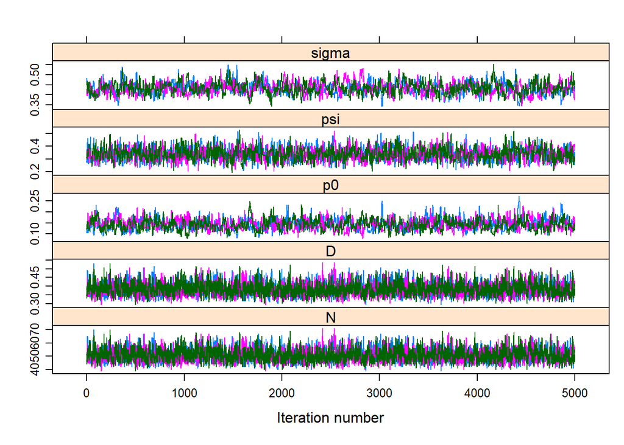

```r
#diagPlot(outNim[,c('N','D','p0','psi', 'sigma')])
xyplot(outNim[,c('N','D','p0','psi', 'sigma')])
```

## Visualización de los centros de actividad

```r
mco <- mcmcOutput(outNim)
s1<-mco$s[,,1] ; Sx<-as.matrix(s1)
s2<-mco$s[,,2] ; Sy<-as.matrix(s2)
z<-mco$z       ; z<- as.matrix(z)

delta<-1.5
Xl<-min(X[,1])-delta
Xu<-max(X[,1])+delta
Yl<-min(X[,2])-delta
Yu<-max(X[,2])+delta
obj<-list(Sx=Sx,Sy=Sy,z=z)

par(mfrow=c(1,1))
Spat<-SCRdensity(obj, nx=100, ny=100, Xl=Xl, Xu=Xu, Yl=Yl, Yu=Yu)
```

```
## mean:  0.3532866
```

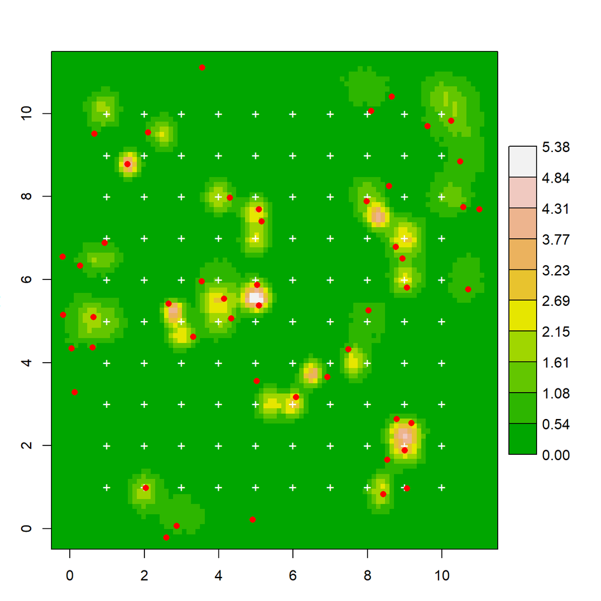

```r
points(X, pch="+", col="white")
points(S, col="red", pch=16)
```

## Referencias

De Valpine, P., Turek, D., Paciorek, C. J., Anderson-Bergman, D., Lang, T., & Bodik, R. (2017). Programming with models: writing statistical algorithms for general model structures with NIMBLE. *Journal of Computational and Graphical Statistics*, 26, 403–413.DOI:10.1080/10618600.2016.1172487

Efford, M. G. (2020). *secr: Spatially explicit capture-recapture models*. R package version 4.3.1. Retrieved from https://cran.r-project.org/package=secr

Jiménez, J., Augustine, B. C., Linden, D. W., Chandler, R. B., & Royle, J. A. (2021). Spatial capture–recapture with random thinning for unidentified encounters. *Ecology and Evolution, 11*(3), 1187–1198. doi:10.1002/ece3.7091

R Core Team. (2022). *R: A language and environment for statistical computing. R Foundation for Statistical Computing*. Vienna, Austria. Retrieved from https://www.r-project.org/.

Royle, J. A., Chandler, R. B., Sollmann, R., & Gardner, B. (2014). *Spatial capture-recapture*. Waltham, Massachusetts: Elsevier, Academic Press. doi:10.1016/B978-0-12-405939-9.00026-8

Sutherland, C. S., Royle, J. A., & Linden, D. W. (2018). *oSCR: Multi-Session Sex-Structured Spatial Capture- Recapture Models*. R package version 0.42.0.